# Risk Factor Analysis

## Outcome Variable

**Outcome Variable:** haz

## Predictor Variables

**Intervention Variable:** mbmi

**Adjustment Set:**

- arm
- W_mage
- meducyrs
- feducyrs
- hhwealth_quart
- brthmon
- W_parity
- impfloor
- impsan
- safeh20
- W_gagebrth
- W_birthwt
- W_birthlen
- vagbrth
- parity
- delta_W_mage
- delta_meducyrs
- delta_feducyrs
- delta_hhwealth_quart
- delta_brthmon
- delta_W_parity
- delta_impfloor
- delta_impsan
- delta_safeh20
- delta_W_gagebrth
- delta_W_birthwt
- delta_W_birthlen
- delta_vagbrth
- delta_parity

## Stratifying Variables

The analysis was stratified on these variable(s):

- agecat
- studyid
- country

## Data Summary

| agecat | studyid | country | mbmi | n_cell | n | outcome_variable |
| --- | --- | --- | --- | --- | --- | --- |
| 6 months | ki0047075b-MAL-ED | BANGLADESH | Normal weight | 209 | 241 | haz |
| 6 months | ki0047075b-MAL-ED | BANGLADESH | Underweight | 32 | 241 | haz |
| 6 months | ki0047075b-MAL-ED | BRAZIL | Normal weight | 199 | 208 | haz |
| 6 months | ki0047075b-MAL-ED | BRAZIL | Underweight | 9 | 208 | haz |
| 6 months | ki0047075b-MAL-ED | INDIA | Normal weight | 186 | 235 | haz |
| 6 months | ki0047075b-MAL-ED | INDIA | Underweight | 49 | 235 | haz |
| 6 months | ki0047075b-MAL-ED | NEPAL | Normal weight | 236 | 236 | haz |
| 6 months | ki0047075b-MAL-ED | NEPAL | Underweight | 0 | 236 | haz |
| 6 months | ki0047075b-MAL-ED | PERU | Normal weight | 267 | 272 | haz |
| 6 months | ki0047075b-MAL-ED | PERU | Underweight | 5 | 272 | haz |
| 6 months | ki0047075b-MAL-ED | SOUTH AFRICA | Normal weight | 242 | 249 | haz |
| 6 months | ki0047075b-MAL-ED | SOUTH AFRICA | Underweight | 7 | 249 | haz |
| 6 months | ki0047075b-MAL-ED | TANZANIA, UNITED REPUBLIC OF | Normal weight | 233 | 247 | haz |
| 6 months | ki0047075b-MAL-ED | TANZANIA, UNITED REPUBLIC OF | Underweight | 14 | 247 | haz |
| 6 months | ki1000304b-SAS-CompFeed | INDIA | Normal weight | 904 | 1228 | haz |
| 6 months | ki1000304b-SAS-CompFeed | INDIA | Underweight | 324 | 1228 | haz |
| 6 months | ki1017093-NIH-Birth | BANGLADESH | Normal weight | 444 | 537 | haz |
| 6 months | ki1017093-NIH-Birth | BANGLADESH | Underweight | 93 | 537 | haz |
| 6 months | ki1017093b-PROVIDE | BANGLADESH | Normal weight | 498 | 603 | haz |
| 6 months | ki1017093b-PROVIDE | BANGLADESH | Underweight | 105 | 603 | haz |
| 6 months | ki1017093c-NIH-Crypto | BANGLADESH | Normal weight | 648 | 715 | haz |
| 6 months | ki1017093c-NIH-Crypto | BANGLADESH | Underweight | 67 | 715 | haz |
| 6 months | ki1066203-TanzaniaChild2 | TANZANIA, UNITED REPUBLIC OF | Normal weight | 1949 | 1983 | haz |
| 6 months | ki1066203-TanzaniaChild2 | TANZANIA, UNITED REPUBLIC OF | Underweight | 34 | 1983 | haz |
| 6 months | ki1119695-PROBIT | BELARUS | Normal weight | 12522 | 13027 | haz |
| 6 months | ki1119695-PROBIT | BELARUS | Underweight | 505 | 13027 | haz |
| 6 months | ki1126311-ZVITAMBO | ZIMBABWE | Normal weight | 6999 | 7375 | haz |
| 6 months | ki1126311-ZVITAMBO | ZIMBABWE | Underweight | 376 | 7375 | haz |
| 6 months | ki1148112-LCNI-5 | MALAWI | Normal weight | 691 | 836 | haz |
| 6 months | ki1148112-LCNI-5 | MALAWI | Underweight | 145 | 836 | haz |
| 6 months | kiGH5241-JiVitA-3 | BANGLADESH | Normal weight | 10311 | 16760 | haz |
| 6 months | kiGH5241-JiVitA-3 | BANGLADESH | Underweight | 6449 | 16760 | haz |
| 24 months | ki0047075b-MAL-ED | BANGLADESH | Normal weight | 183 | 212 | haz |
| 24 months | ki0047075b-MAL-ED | BANGLADESH | Underweight | 29 | 212 | haz |
| 24 months | ki0047075b-MAL-ED | BRAZIL | Normal weight | 162 | 168 | haz |
| 24 months | ki0047075b-MAL-ED | BRAZIL | Underweight | 6 | 168 | haz |
| 24 months | ki0047075b-MAL-ED | INDIA | Normal weight | 180 | 226 | haz |
| 24 months | ki0047075b-MAL-ED | INDIA | Underweight | 46 | 226 | haz |
| 24 months | ki0047075b-MAL-ED | NEPAL | Normal weight | 228 | 228 | haz |
| 24 months | ki0047075b-MAL-ED | NEPAL | Underweight | 0 | 228 | haz |
| 24 months | ki0047075b-MAL-ED | PERU | Normal weight | 197 | 201 | haz |
| 24 months | ki0047075b-MAL-ED | PERU | Underweight | 4 | 201 | haz |
| 24 months | ki0047075b-MAL-ED | SOUTH AFRICA | Normal weight | 227 | 234 | haz |
| 24 months | ki0047075b-MAL-ED | SOUTH AFRICA | Underweight | 7 | 234 | haz |
| 24 months | ki0047075b-MAL-ED | TANZANIA, UNITED REPUBLIC OF | Normal weight | 203 | 214 | haz |
| 24 months | ki0047075b-MAL-ED | TANZANIA, UNITED REPUBLIC OF | Underweight | 11 | 214 | haz |
| 24 months | ki1017093-NIH-Birth | BANGLADESH | Normal weight | 349 | 429 | haz |
| 24 months | ki1017093-NIH-Birth | BANGLADESH | Underweight | 80 | 429 | haz |
| 24 months | ki1017093b-PROVIDE | BANGLADESH | Normal weight | 477 | 577 | haz |
| 24 months | ki1017093b-PROVIDE | BANGLADESH | Underweight | 100 | 577 | haz |
| 24 months | ki1017093c-NIH-Crypto | BANGLADESH | Normal weight | 471 | 514 | haz |
| 24 months | ki1017093c-NIH-Crypto | BANGLADESH | Underweight | 43 | 514 | haz |
| 24 months | ki1066203-TanzaniaChild2 | TANZANIA, UNITED REPUBLIC OF | Normal weight | 6 | 6 | haz |
| 24 months | ki1066203-TanzaniaChild2 | TANZANIA, UNITED REPUBLIC OF | Underweight | 0 | 6 | haz |
| 24 months | ki1119695-PROBIT | BELARUS | Normal weight | 3863 | 4005 | haz |
| 24 months | ki1119695-PROBIT | BELARUS | Underweight | 142 | 4005 | haz |
| 24 months | ki1126311-ZVITAMBO | ZIMBABWE | Normal weight | 1312 | 1373 | haz |
| 24 months | ki1126311-ZVITAMBO | ZIMBABWE | Underweight | 61 | 1373 | haz |
| 24 months | ki1148112-LCNI-5 | MALAWI | Normal weight | 482 | 577 | haz |
| 24 months | ki1148112-LCNI-5 | MALAWI | Underweight | 95 | 577 | haz |
| 24 months | kiGH5241-JiVitA-3 | BANGLADESH | Normal weight | 5289 | 8599 | haz |
| 24 months | kiGH5241-JiVitA-3 | BANGLADESH | Underweight | 3310 | 8599 | haz |

The following strata were considered:

- agecat: 24 months, studyid: ki0047075b-MAL-ED, country: BANGLADESH
- agecat: 24 months, studyid: ki0047075b-MAL-ED, country: BRAZIL
- agecat: 24 months, studyid: ki0047075b-MAL-ED, country: INDIA
- agecat: 24 months, studyid: ki0047075b-MAL-ED, country: NEPAL
- agecat: 24 months, studyid: ki0047075b-MAL-ED, country: PERU
- agecat: 24 months, studyid: ki0047075b-MAL-ED, country: SOUTH AFRICA
- agecat: 24 months, studyid: ki0047075b-MAL-ED, country: TANZANIA, UNITED REPUBLIC OF
- agecat: 24 months, studyid: ki1017093-NIH-Birth, country: BANGLADESH
- agecat: 24 months, studyid: ki1017093b-PROVIDE, country: BANGLADESH
- agecat: 24 months, studyid: ki1017093c-NIH-Crypto, country: BANGLADESH
- agecat: 24 months, studyid: ki1066203-TanzaniaChild2, country: TANZANIA, UNITED REPUBLIC OF
- agecat: 24 months, studyid: ki1119695-PROBIT, country: BELARUS
- agecat: 24 months, studyid: ki1126311-ZVITAMBO, country: ZIMBABWE
- agecat: 24 months, studyid: ki1148112-LCNI-5, country: MALAWI
- agecat: 24 months, studyid: kiGH5241-JiVitA-3, country: BANGLADESH
- agecat: 6 months, studyid: ki0047075b-MAL-ED, country: BANGLADESH
- agecat: 6 months, studyid: ki0047075b-MAL-ED, country: BRAZIL
- agecat: 6 months, studyid: ki0047075b-MAL-ED, country: INDIA
- agecat: 6 months, studyid: ki0047075b-MAL-ED, country: NEPAL
- agecat: 6 months, studyid: ki0047075b-MAL-ED, country: PERU
- agecat: 6 months, studyid: ki0047075b-MAL-ED, country: SOUTH AFRICA
- agecat: 6 months, studyid: ki0047075b-MAL-ED, country: TANZANIA, UNITED REPUBLIC OF
- agecat: 6 months, studyid: ki1000304b-SAS-CompFeed, country: INDIA
- agecat: 6 months, studyid: ki1017093-NIH-Birth, country: BANGLADESH
- agecat: 6 months, studyid: ki1017093b-PROVIDE, country: BANGLADESH
- agecat: 6 months, studyid: ki1017093c-NIH-Crypto, country: BANGLADESH
- agecat: 6 months, studyid: ki1066203-TanzaniaChild2, country: TANZANIA, UNITED REPUBLIC OF
- agecat: 6 months, studyid: ki1119695-PROBIT, country: BELARUS
- agecat: 6 months, studyid: ki1126311-ZVITAMBO, country: ZIMBABWE
- agecat: 6 months, studyid: ki1148112-LCNI-5, country: MALAWI
- agecat: 6 months, studyid: kiGH5241-JiVitA-3, country: BANGLADESH

### Dropped Strata

Some strata were dropped due to rare outcomes:

- agecat: 6 months, studyid: ki0047075b-MAL-ED, country: NEPAL
- agecat: 24 months, studyid: ki0047075b-MAL-ED, country: NEPAL
- agecat: 24 months, studyid: ki0047075b-MAL-ED, country: PERU
- agecat: 24 months, studyid: ki1066203-TanzaniaChild2, country: TANZANIA, UNITED REPUBLIC OF

## Methods Detail

We’re interested in the causal parameters $E[Y_a]$ for all values of $a \in \mathcal{A}$. These parameters represent the mean outcome if, possibly contrary to fact, we intervened to set all units to have $A=a$. Under the randomization and positivity assumptions, these are identified by the statistical parameters $\psi_a=E_W[E_{Y|A,W}(Y|A=a,W)]$. In addition, we’re interested in the mean of $Y$, $E[Y]$ under no intervention (the observed mean). We will estimate these parameters by using SuperLearner to fit the relevant likelihood factors – $E_{Y|A,W}(Y|A=a,W)$ and $p(A=a|W)$, and then updating our likelihood fit using a joint TMLE.

For unadjusted analyses ($W=\{\}$), initial likelihoods were estimated using Lrnr_glm to estimate the simple $E(Y|A)$ and Lrnr_mean to estimate $p(A)$. For adjusted analyses, a small library containing Lrnr_glmnet, Lrnr_xgboost, and Lrnr_mean was used.

Having estimated these parameters, we will then use the delta method to estimate relative risks and attributable risks relative to a prespecified baseline level of $A$.

# Results Detail

## Results Plots

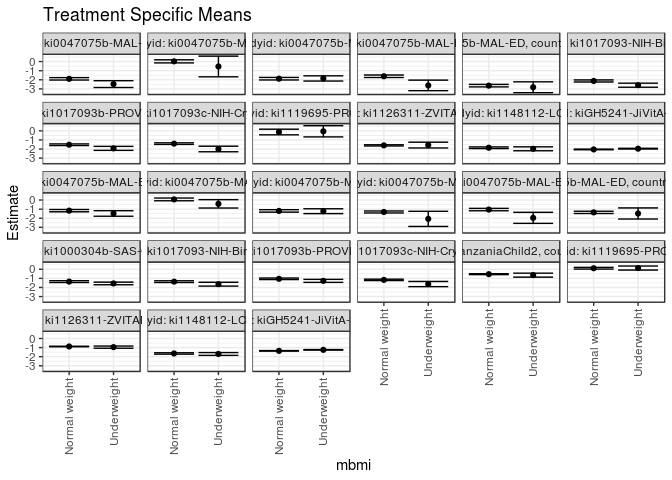

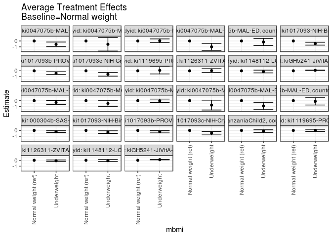

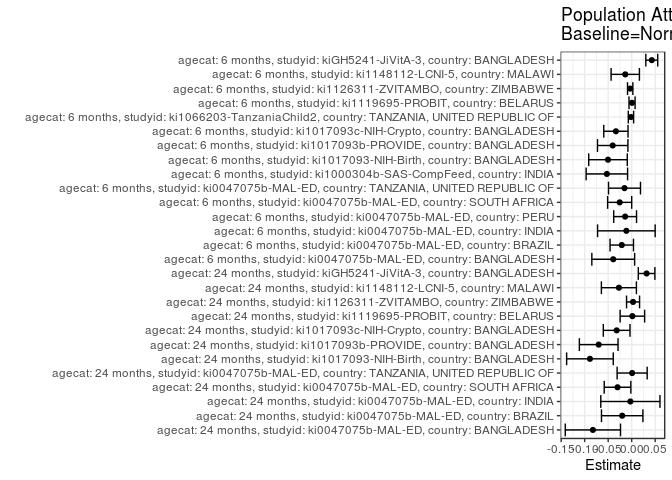

## Results Table

### Parameter: TSM

| agecat | studyid | country | intervention_level | baseline_level | estimate | ci_lower | ci_upper |
| --- | --- | --- | --- | --- | --- | --- | --- |
| 6 months | ki0047075b-MAL-ED | BANGLADESH | Normal weight | NA | -1.1657280 | -1.2918892 | -1.0395668 |
| 6 months | ki0047075b-MAL-ED | BANGLADESH | Underweight | NA | -1.4750758 | -1.7803655 | -1.1697861 |
| 6 months | ki0047075b-MAL-ED | BRAZIL | Normal weight | NA | 0.0708375 | -0.0781476 | 0.2198227 |
| 6 months | ki0047075b-MAL-ED | BRAZIL | Underweight | NA | -0.4164815 | -0.8769172 | 0.0439543 |
| 6 months | ki0047075b-MAL-ED | INDIA | Normal weight | NA | -1.1946342 | -1.3278019 | -1.0614665 |
| 6 months | ki0047075b-MAL-ED | INDIA | Underweight | NA | -1.2242433 | -1.4909411 | -0.9575455 |
| 6 months | ki0047075b-MAL-ED | PERU | Normal weight | NA | -1.3101467 | -1.4185443 | -1.2017491 |
| 6 months | ki0047075b-MAL-ED | PERU | Underweight | NA | -2.0693333 | -2.9031517 | -1.2355150 |
| 6 months | ki0047075b-MAL-ED | SOUTH AFRICA | Normal weight | NA | -1.0471625 | -1.1780920 | -0.9162331 |
| 6 months | ki0047075b-MAL-ED | SOUTH AFRICA | Underweight | NA | -1.9571429 | -2.5636947 | -1.3505910 |
| 6 months | ki0047075b-MAL-ED | TANZANIA, UNITED REPUBLIC OF | Normal weight | NA | -1.3534722 | -1.4773665 | -1.2295780 |
| 6 months | ki0047075b-MAL-ED | TANZANIA, UNITED REPUBLIC OF | Underweight | NA | -1.4772789 | -2.0873031 | -0.8672548 |
| 6 months | ki1000304b-SAS-CompFeed | INDIA | Normal weight | NA | -1.3540657 | -1.4540297 | -1.2541016 |
| 6 months | ki1000304b-SAS-CompFeed | INDIA | Underweight | NA | -1.5573991 | -1.7019413 | -1.4128568 |
| 6 months | ki1017093-NIH-Birth | BANGLADESH | Normal weight | NA | -1.3569918 | -1.4519946 | -1.2619891 |
| 6 months | ki1017093-NIH-Birth | BANGLADESH | Underweight | NA | -1.6400860 | -1.8512888 | -1.4288832 |
| 6 months | ki1017093b-PROVIDE | BANGLADESH | Normal weight | NA | -1.0491343 | -1.1319655 | -0.9663032 |
| 6 months | ki1017093b-PROVIDE | BANGLADESH | Underweight | NA | -1.2742776 | -1.4383810 | -1.1101742 |
| 6 months | ki1017093c-NIH-Crypto | BANGLADESH | Normal weight | NA | -1.1650657 | -1.2386360 | -1.0914954 |
| 6 months | ki1017093c-NIH-Crypto | BANGLADESH | Underweight | NA | -1.6246579 | -1.9095715 | -1.3397443 |
| 6 months | ki1066203-TanzaniaChild2 | TANZANIA, UNITED REPUBLIC OF | Normal weight | NA | -0.5390108 | -0.5892695 | -0.4887520 |
| 6 months | ki1066203-TanzaniaChild2 | TANZANIA, UNITED REPUBLIC OF | Underweight | NA | -0.6440409 | -0.8630712 | -0.4250105 |
| 6 months | ki1119695-PROBIT | BELARUS | Normal weight | NA | 0.1146128 | 0.0219995 | 0.2072260 |
| 6 months | ki1119695-PROBIT | BELARUS | Underweight | NA | 0.1351817 | -0.0861889 | 0.3565522 |
| 6 months | ki1126311-ZVITAMBO | ZIMBABWE | Normal weight | NA | -0.8768525 | -0.9049404 | -0.8487646 |
| 6 months | ki1126311-ZVITAMBO | ZIMBABWE | Underweight | NA | -0.9468671 | -1.0665465 | -0.8271877 |
| 6 months | ki1148112-LCNI-5 | MALAWI | Normal weight | NA | -1.6441018 | -1.7224068 | -1.5657969 |
| 6 months | ki1148112-LCNI-5 | MALAWI | Underweight | NA | -1.6973655 | -1.8520605 | -1.5426705 |
| 6 months | kiGH5241-JiVitA-3 | BANGLADESH | Normal weight | NA | -1.3567140 | -1.3834167 | -1.3300113 |
| 6 months | kiGH5241-JiVitA-3 | BANGLADESH | Underweight | NA | -1.2457008 | -1.2757551 | -1.2156465 |
| 24 months | ki0047075b-MAL-ED | BANGLADESH | Normal weight | NA | -1.8958632 | -2.0268120 | -1.7649145 |
| 24 months | ki0047075b-MAL-ED | BANGLADESH | Underweight | NA | -2.4754319 | -2.8503529 | -2.1005109 |
| 24 months | ki0047075b-MAL-ED | BRAZIL | Normal weight | NA | 0.0261008 | -0.1439691 | 0.1961708 |
| 24 months | ki0047075b-MAL-ED | BRAZIL | Underweight | NA | -0.5391667 | -1.6773310 | 0.5989977 |
| 24 months | ki0047075b-MAL-ED | INDIA | Normal weight | NA | -1.8816732 | -2.0220975 | -1.7412490 |
| 24 months | ki0047075b-MAL-ED | INDIA | Underweight | NA | -1.8500666 | -2.1358363 | -1.5642969 |
| 24 months | ki0047075b-MAL-ED | SOUTH AFRICA | Normal weight | NA | -1.6131241 | -1.7506877 | -1.4755605 |
| 24 months | ki0047075b-MAL-ED | SOUTH AFRICA | Underweight | NA | -2.6192857 | -3.1998173 | -2.0387542 |
| 24 months | ki0047075b-MAL-ED | TANZANIA, UNITED REPUBLIC OF | Normal weight | NA | -2.6465391 | -2.7848755 | -2.5082028 |
| 24 months | ki0047075b-MAL-ED | TANZANIA, UNITED REPUBLIC OF | Underweight | NA | -2.8229616 | -3.4210964 | -2.2248267 |
| 24 months | ki1017093-NIH-Birth | BANGLADESH | Normal weight | NA | -2.1302834 | -2.2432924 | -2.0172745 |
| 24 months | ki1017093-NIH-Birth | BANGLADESH | Underweight | NA | -2.5955578 | -2.8172000 | -2.3739157 |
| 24 months | ki1017093b-PROVIDE | BANGLADESH | Normal weight | NA | -1.5300809 | -1.6202073 | -1.4399546 |
| 24 months | ki1017093b-PROVIDE | BANGLADESH | Underweight | NA | -1.9292929 | -2.1476750 | -1.7109108 |
| 24 months | ki1017093c-NIH-Crypto | BANGLADESH | Normal weight | NA | -1.4092763 | -1.4964694 | -1.3220832 |
| 24 months | ki1017093c-NIH-Crypto | BANGLADESH | Underweight | NA | -1.9977392 | -2.3049252 | -1.6905531 |
| 24 months | ki1119695-PROBIT | BELARUS | Normal weight | NA | -0.1337013 | -0.4436579 | 0.1762553 |
| 24 months | ki1119695-PROBIT | BELARUS | Underweight | NA | -0.0544461 | -0.6692237 | 0.5603315 |
| 24 months | ki1126311-ZVITAMBO | ZIMBABWE | Normal weight | NA | -1.6012444 | -1.6646781 | -1.5378107 |
| 24 months | ki1126311-ZVITAMBO | ZIMBABWE | Underweight | NA | -1.5691175 | -1.8864000 | -1.2518350 |
| 24 months | ki1148112-LCNI-5 | MALAWI | Normal weight | NA | -1.8579710 | -1.9477980 | -1.7681440 |
| 24 months | ki1148112-LCNI-5 | MALAWI | Underweight | NA | -1.9765308 | -2.1945379 | -1.7585237 |
| 24 months | kiGH5241-JiVitA-3 | BANGLADESH | Normal weight | NA | -2.0454671 | -2.0787472 | -2.0121869 |
| 24 months | kiGH5241-JiVitA-3 | BANGLADESH | Underweight | NA | -1.9631693 | -2.0019432 | -1.9243954 |

### Parameter: E(Y)

| agecat | studyid | country | intervention_level | baseline_level | estimate | ci_lower | ci_upper |
| --- | --- | --- | --- | --- | --- | --- | --- |
| 6 months | ki0047075b-MAL-ED | BANGLADESH | NA | NA | -1.2049931 | -1.3222136 | -1.0877726 |
| 6 months | ki0047075b-MAL-ED | BRAZIL | NA | NA | 0.0497516 | -0.0948051 | 0.1943083 |
| 6 months | ki0047075b-MAL-ED | INDIA | NA | NA | -1.2059574 | -1.3243030 | -1.0876119 |
| 6 months | ki0047075b-MAL-ED | PERU | NA | NA | -1.3241023 | -1.4325083 | -1.2156964 |
| 6 months | ki0047075b-MAL-ED | SOUTH AFRICA | NA | NA | -1.0727443 | -1.2024880 | -0.9430006 |
| 6 months | ki0047075b-MAL-ED | TANZANIA, UNITED REPUBLIC OF | NA | NA | -1.3687449 | -1.4907629 | -1.2467270 |
| 6 months | ki1000304b-SAS-CompFeed | INDIA | NA | NA | -1.4068893 | -1.4981242 | -1.3156543 |
| 6 months | ki1017093-NIH-Birth | BANGLADESH | NA | NA | -1.4073821 | -1.4960598 | -1.3187043 |
| 6 months | ki1017093b-PROVIDE | BANGLADESH | NA | NA | -1.0895301 | -1.1639589 | -1.0151013 |
| 6 months | ki1017093c-NIH-Crypto | BANGLADESH | NA | NA | -1.1986783 | -1.2700937 | -1.1272630 |
| 6 months | ki1066203-TanzaniaChild2 | TANZANIA, UNITED REPUBLIC OF | NA | NA | -0.5405711 | -0.5899965 | -0.4911457 |
| 6 months | ki1119695-PROBIT | BELARUS | NA | NA | 0.1153731 | 0.0222128 | 0.2085334 |
| 6 months | ki1126311-ZVITAMBO | ZIMBABWE | NA | NA | -0.8800508 | -0.9074511 | -0.8526506 |
| 6 months | ki1148112-LCNI-5 | MALAWI | NA | NA | -1.6577751 | -1.7275296 | -1.5880207 |
| 6 months | kiGH5241-JiVitA-3 | BANGLADESH | NA | NA | -1.3140048 | -1.3371141 | -1.2908955 |
| 24 months | ki0047075b-MAL-ED | BANGLADESH | NA | NA | -1.9783962 | -2.1050210 | -1.8517715 |
| 24 months | ki0047075b-MAL-ED | BRAZIL | NA | NA | 0.0059127 | -0.1637934 | 0.1756188 |
| 24 months | ki0047075b-MAL-ED | INDIA | NA | NA | -1.8844690 | -2.0097879 | -1.7591502 |
| 24 months | ki0047075b-MAL-ED | SOUTH AFRICA | NA | NA | -1.6432229 | -1.7795844 | -1.5068615 |
| 24 months | ki0047075b-MAL-ED | TANZANIA, UNITED REPUBLIC OF | NA | NA | -2.6455607 | -2.7807256 | -2.5103959 |
| 24 months | ki1017093-NIH-Birth | BANGLADESH | NA | NA | -2.2190579 | -2.3217459 | -2.1163699 |
| 24 months | ki1017093b-PROVIDE | BANGLADESH | NA | NA | -1.6002600 | -1.6836163 | -1.5169036 |
| 24 months | ki1017093c-NIH-Crypto | BANGLADESH | NA | NA | -1.4412646 | -1.5249156 | -1.3576135 |
| 24 months | ki1119695-PROBIT | BELARUS | NA | NA | -0.1322181 | -0.4300523 | 0.1656161 |
| 24 months | ki1126311-ZVITAMBO | ZIMBABWE | NA | NA | -1.5983212 | -1.6605141 | -1.5361283 |
| 24 months | ki1148112-LCNI-5 | MALAWI | NA | NA | -1.8851820 | -1.9664818 | -1.8038822 |
| 24 months | kiGH5241-JiVitA-3 | BANGLADESH | NA | NA | -2.0137632 | -2.0415122 | -1.9860142 |

### Parameter: ATE

| agecat | studyid | country | intervention_level | baseline_level | estimate | ci_lower | ci_upper |
| --- | --- | --- | --- | --- | --- | --- | --- |
| 6 months | ki0047075b-MAL-ED | BANGLADESH | Normal weight | Normal weight | 0.0000000 | 0.0000000 | 0.0000000 |
| 6 months | ki0047075b-MAL-ED | BANGLADESH | Underweight | Normal weight | -0.3093478 | -0.6408306 | 0.0221349 |
| 6 months | ki0047075b-MAL-ED | BRAZIL | Normal weight | Normal weight | 0.0000000 | 0.0000000 | 0.0000000 |
| 6 months | ki0047075b-MAL-ED | BRAZIL | Underweight | Normal weight | -0.4873190 | -0.9712587 | -0.0033793 |
| 6 months | ki0047075b-MAL-ED | INDIA | Normal weight | Normal weight | 0.0000000 | 0.0000000 | 0.0000000 |
| 6 months | ki0047075b-MAL-ED | INDIA | Underweight | Normal weight | -0.0296091 | -0.3283124 | 0.2690941 |
| 6 months | ki0047075b-MAL-ED | PERU | Normal weight | Normal weight | 0.0000000 | 0.0000000 | 0.0000000 |
| 6 months | ki0047075b-MAL-ED | PERU | Underweight | Normal weight | -0.7591866 | -1.6000214 | 0.0816481 |
| 6 months | ki0047075b-MAL-ED | SOUTH AFRICA | Normal weight | Normal weight | 0.0000000 | 0.0000000 | 0.0000000 |
| 6 months | ki0047075b-MAL-ED | SOUTH AFRICA | Underweight | Normal weight | -0.9099803 | -1.5305024 | -0.2894583 |
| 6 months | ki0047075b-MAL-ED | TANZANIA, UNITED REPUBLIC OF | Normal weight | Normal weight | 0.0000000 | 0.0000000 | 0.0000000 |
| 6 months | ki0047075b-MAL-ED | TANZANIA, UNITED REPUBLIC OF | Underweight | Normal weight | -0.1238067 | -0.7444949 | 0.4968816 |
| 6 months | ki1000304b-SAS-CompFeed | INDIA | Normal weight | Normal weight | 0.0000000 | 0.0000000 | 0.0000000 |
| 6 months | ki1000304b-SAS-CompFeed | INDIA | Underweight | Normal weight | -0.2033334 | -0.3620141 | -0.0446527 |
| 6 months | ki1017093-NIH-Birth | BANGLADESH | Normal weight | Normal weight | 0.0000000 | 0.0000000 | 0.0000000 |
| 6 months | ki1017093-NIH-Birth | BANGLADESH | Underweight | Normal weight | -0.2830941 | -0.5097203 | -0.0564680 |
| 6 months | ki1017093b-PROVIDE | BANGLADESH | Normal weight | Normal weight | 0.0000000 | 0.0000000 | 0.0000000 |
| 6 months | ki1017093b-PROVIDE | BANGLADESH | Underweight | Normal weight | -0.2251433 | -0.4090269 | -0.0412597 |
| 6 months | ki1017093c-NIH-Crypto | BANGLADESH | Normal weight | Normal weight | 0.0000000 | 0.0000000 | 0.0000000 |
| 6 months | ki1017093c-NIH-Crypto | BANGLADESH | Underweight | Normal weight | -0.4595922 | -0.7546173 | -0.1645671 |
| 6 months | ki1066203-TanzaniaChild2 | TANZANIA, UNITED REPUBLIC OF | Normal weight | Normal weight | 0.0000000 | 0.0000000 | 0.0000000 |
| 6 months | ki1066203-TanzaniaChild2 | TANZANIA, UNITED REPUBLIC OF | Underweight | Normal weight | -0.1050301 | -0.3284467 | 0.1183865 |
| 6 months | ki1119695-PROBIT | BELARUS | Normal weight | Normal weight | 0.0000000 | 0.0000000 | 0.0000000 |
| 6 months | ki1119695-PROBIT | BELARUS | Underweight | Normal weight | 0.0205689 | -0.1659112 | 0.2070490 |
| 6 months | ki1126311-ZVITAMBO | ZIMBABWE | Normal weight | Normal weight | 0.0000000 | 0.0000000 | 0.0000000 |
| 6 months | ki1126311-ZVITAMBO | ZIMBABWE | Underweight | Normal weight | -0.0700146 | -0.1920442 | 0.0520150 |
| 6 months | ki1148112-LCNI-5 | MALAWI | Normal weight | Normal weight | 0.0000000 | 0.0000000 | 0.0000000 |
| 6 months | ki1148112-LCNI-5 | MALAWI | Underweight | Normal weight | -0.0532637 | -0.2268702 | 0.1203427 |
| 6 months | kiGH5241-JiVitA-3 | BANGLADESH | Normal weight | Normal weight | 0.0000000 | 0.0000000 | 0.0000000 |
| 6 months | kiGH5241-JiVitA-3 | BANGLADESH | Underweight | Normal weight | 0.1110132 | 0.0783943 | 0.1436320 |
| 24 months | ki0047075b-MAL-ED | BANGLADESH | Normal weight | Normal weight | 0.0000000 | 0.0000000 | 0.0000000 |
| 24 months | ki0047075b-MAL-ED | BANGLADESH | Underweight | Normal weight | -0.5795687 | -0.9748981 | -0.1842392 |
| 24 months | ki0047075b-MAL-ED | BRAZIL | Normal weight | Normal weight | 0.0000000 | 0.0000000 | 0.0000000 |
| 24 months | ki0047075b-MAL-ED | BRAZIL | Underweight | Normal weight | -0.5652675 | -1.7160680 | 0.5855330 |
| 24 months | ki0047075b-MAL-ED | INDIA | Normal weight | Normal weight | 0.0000000 | 0.0000000 | 0.0000000 |
| 24 months | ki0047075b-MAL-ED | INDIA | Underweight | Normal weight | 0.0316066 | -0.2863799 | 0.3495932 |
| 24 months | ki0047075b-MAL-ED | SOUTH AFRICA | Normal weight | Normal weight | 0.0000000 | 0.0000000 | 0.0000000 |
| 24 months | ki0047075b-MAL-ED | SOUTH AFRICA | Underweight | Normal weight | -1.0061616 | -1.6027692 | -0.4095540 |
| 24 months | ki0047075b-MAL-ED | TANZANIA, UNITED REPUBLIC OF | Normal weight | Normal weight | 0.0000000 | 0.0000000 | 0.0000000 |
| 24 months | ki0047075b-MAL-ED | TANZANIA, UNITED REPUBLIC OF | Underweight | Normal weight | -0.1764224 | -0.7881141 | 0.4352692 |
| 24 months | ki1017093-NIH-Birth | BANGLADESH | Normal weight | Normal weight | 0.0000000 | 0.0000000 | 0.0000000 |
| 24 months | ki1017093-NIH-Birth | BANGLADESH | Underweight | Normal weight | -0.4652744 | -0.7124168 | -0.2181320 |
| 24 months | ki1017093b-PROVIDE | BANGLADESH | Normal weight | Normal weight | 0.0000000 | 0.0000000 | 0.0000000 |
| 24 months | ki1017093b-PROVIDE | BANGLADESH | Underweight | Normal weight | -0.3992120 | -0.6347902 | -0.1636337 |
| 24 months | ki1017093c-NIH-Crypto | BANGLADESH | Normal weight | Normal weight | 0.0000000 | 0.0000000 | 0.0000000 |
| 24 months | ki1017093c-NIH-Crypto | BANGLADESH | Underweight | Normal weight | -0.5884629 | -0.9097223 | -0.2672035 |
| 24 months | ki1119695-PROBIT | BELARUS | Normal weight | Normal weight | 0.0000000 | 0.0000000 | 0.0000000 |
| 24 months | ki1119695-PROBIT | BELARUS | Underweight | Normal weight | 0.0792552 | -0.5340796 | 0.6925900 |
| 24 months | ki1126311-ZVITAMBO | ZIMBABWE | Normal weight | Normal weight | 0.0000000 | 0.0000000 | 0.0000000 |
| 24 months | ki1126311-ZVITAMBO | ZIMBABWE | Underweight | Normal weight | 0.0321269 | -0.2911301 | 0.3553840 |
| 24 months | ki1148112-LCNI-5 | MALAWI | Normal weight | Normal weight | 0.0000000 | 0.0000000 | 0.0000000 |
| 24 months | ki1148112-LCNI-5 | MALAWI | Underweight | Normal weight | -0.1185598 | -0.3544588 | 0.1173393 |
| 24 months | kiGH5241-JiVitA-3 | BANGLADESH | Normal weight | Normal weight | 0.0000000 | 0.0000000 | 0.0000000 |
| 24 months | kiGH5241-JiVitA-3 | BANGLADESH | Underweight | Normal weight | 0.0822978 | 0.0367523 | 0.1278433 |

### Parameter: PAR

| agecat | studyid | country | intervention_level | baseline_level | estimate | ci_lower | ci_upper |
| --- | --- | --- | --- | --- | --- | --- | --- |
| 6 months | ki0047075b-MAL-ED | BANGLADESH | Normal weight | NA | -0.0392651 | -0.0847831 | 0.0062529 |
| 6 months | ki0047075b-MAL-ED | BRAZIL | Normal weight | NA | -0.0210859 | -0.0460040 | 0.0038322 |
| 6 months | ki0047075b-MAL-ED | INDIA | Normal weight | NA | -0.0113233 | -0.0725771 | 0.0499305 |
| 6 months | ki0047075b-MAL-ED | PERU | Normal weight | NA | -0.0139556 | -0.0382312 | 0.0103199 |
| 6 months | ki0047075b-MAL-ED | SOUTH AFRICA | Normal weight | NA | -0.0255818 | -0.0511699 | 0.0000064 |
| 6 months | ki0047075b-MAL-ED | TANZANIA, UNITED REPUBLIC OF | Normal weight | NA | -0.0152727 | -0.0492726 | 0.0187272 |
| 6 months | ki1000304b-SAS-CompFeed | INDIA | Normal weight | NA | -0.0528236 | -0.0969186 | -0.0087286 |
| 6 months | ki1017093-NIH-Birth | BANGLADESH | Normal weight | NA | -0.0503902 | -0.0913976 | -0.0093828 |
| 6 months | ki1017093b-PROVIDE | BANGLADESH | Normal weight | NA | -0.0403958 | -0.0727552 | -0.0080364 |
| 6 months | ki1017093c-NIH-Crypto | BANGLADESH | Normal weight | NA | -0.0336126 | -0.0594379 | -0.0077874 |
| 6 months | ki1066203-TanzaniaChild2 | TANZANIA, UNITED REPUBLIC OF | Normal weight | NA | -0.0015604 | -0.0072082 | 0.0040875 |
| 6 months | ki1119695-PROBIT | BELARUS | Normal weight | NA | 0.0007603 | -0.0057014 | 0.0072220 |
| 6 months | ki1126311-ZVITAMBO | ZIMBABWE | Normal weight | NA | -0.0031983 | -0.0088579 | 0.0024612 |
| 6 months | ki1148112-LCNI-5 | MALAWI | Normal weight | NA | -0.0136733 | -0.0437937 | 0.0164471 |
| 6 months | kiGH5241-JiVitA-3 | BANGLADESH | Normal weight | NA | 0.0427092 | 0.0300671 | 0.0553514 |
| 24 months | ki0047075b-MAL-ED | BANGLADESH | Normal weight | NA | -0.0825330 | -0.1412857 | -0.0237803 |
| 24 months | ki0047075b-MAL-ED | BRAZIL | Normal weight | NA | -0.0201881 | -0.0642601 | 0.0238838 |
| 24 months | ki0047075b-MAL-ED | INDIA | Normal weight | NA | -0.0027958 | -0.0657352 | 0.0601436 |
| 24 months | ki0047075b-MAL-ED | SOUTH AFRICA | Normal weight | NA | -0.0300989 | -0.0584341 | -0.0017637 |
| 24 months | ki0047075b-MAL-ED | TANZANIA, UNITED REPUBLIC OF | Normal weight | NA | 0.0009784 | -0.0309747 | 0.0329315 |
| 24 months | ki1017093-NIH-Birth | BANGLADESH | Normal weight | NA | -0.0887744 | -0.1383849 | -0.0391640 |
| 24 months | ki1017093b-PROVIDE | BANGLADESH | Normal weight | NA | -0.0701790 | -0.1112984 | -0.0290597 |
| 24 months | ki1017093c-NIH-Crypto | BANGLADESH | Normal weight | NA | -0.0319883 | -0.0603478 | -0.0036288 |
| 24 months | ki1119695-PROBIT | BELARUS | Normal weight | NA | 0.0014833 | -0.0245843 | 0.0275509 |
| 24 months | ki1126311-ZVITAMBO | ZIMBABWE | Normal weight | NA | 0.0029232 | -0.0109307 | 0.0167771 |
| 24 months | ki1148112-LCNI-5 | MALAWI | Normal weight | NA | -0.0272109 | -0.0644579 | 0.0100360 |
| 24 months | kiGH5241-JiVitA-3 | BANGLADESH | Normal weight | NA | 0.0317039 | 0.0140654 | 0.0493423 |